# Singular Value Decomposition and Measures of Democracy

Machine Learning for Social Sciences (Homework #7)

Saara Ghani

2024-03-25

# SVD and Measures of Democracy Exercises

## Assignment Set Up

In this assignment you will be working with the Varieties of Democracy (V-Dem) data. The V-Dem data is an effort by thousands of in-country experts who evaluate qualities of democracy for almost every country. It rates the status of democracy according to five principles: electoral, liberal, participatory, deliberative, and egalitarian. Some measures go back to 1789.

For this analysis, we will focus on data from 2022 regarding the media. There are ten measures regarding the status of the media.

- Government censorship effort (v2mecenefm)
- Internet censorship effort (v2mecenefi)
- Internet availability (v2mecenefibin)
- Print/broadcast media critical (v2mecrit)
- Print/broadcast media perspectives (v2merange)
- Female journalists (v2mefemjrn)
- Harassment of journalists (v2meharjrn)
- Media self-censorship (v2meslfcen)
- Media bias (v2mebias)
- Media corrupt (v2mecorrpt)

The female journalist measure (v2mefemjrn) records the percentage of journalists who are female. Internet availability (v2mecenefibin) is (almost) a +1 (yes) and -1 (no) but the measurement model involves some scaling and imputation (thus the “almost”). All other measures are unitless scales indicating the level of the particular measure. For a detailed description of these 10 measures, see page 201 in the [V-Dem codebook](https://v-dem.net/documents/24/codebook_v13.pdf). To learn details of the methodology for constructing these measures see Page 22 of the [V-Dem Varieties of Democracy Methodology v13](https://www.v-dem.net/documents/26/methodology_v13.pdf).

We will use singular value decomposition to explore these data. Install and load the vdemdata R package to conveniently access the dataset.

```r
setwd("/Users/saaraghani/Desktop/Academic/Spring24/CRIM4012/HW")
```

```r
# Code Given by Instructor:
library(dplyr)
# one time make sure to get the vdemdata
# devtools::install_github("vdeminstitute/vdemdata")
library(vdemdata)
```

Select the country identifiers, the year, the ten media measures, and subset to the 2022 data.

```r
# Code Given by Instructor:
varsID <- c("country_name","histname","country_text_id","year")
varsMedia <- c("v2mecenefm","v2mecenefi","v2mecenefibin","v2mecrit",
               "v2merange","v2mefemjrn","v2meharjrn","v2meslfcen",
               "v2mebias","v2mecorrpt")
dMedia <- vdem[c(varsID,varsMedia)] |>
  filter(year==2022)
```

Create a matrix X that has as columns the 179 countries in the 2022 data with each of the ten rows containing the media measurements. Also center and rescale each column.

```r
# Code Given by Instructor:
X <- data.matrix(dMedia[varsMedia]) |> scale() |> t()
```

### Question 1:

**Using R, compute the singular value decomposition of X.**

```r
svdX <- svd(X)
```

## Question 2:

**Show that UDv1, where v1 is the first row of V, reconstructs the media data for the first column of X.**

```r
UDv1 <- with(svdX, u %*% diag(d) %*% v[1,])
all(abs(UDv1 - X[,1]) < 1e-10)
```

```
## [1] TRUE
```

## Question 3:

**Compute U’U and V’V. What kind of matrices are these?**

```r
with(svdX, t(u) %*% u) |> zapsmall()
```

```
##       [,1] [,2] [,3] [,4] [,5] [,6] [,7] [,8] [,9] [,10]
##  [1,]    1    0    0    0    0    0    0    0    0     0
##  [2,]    0    1    0    0    0    0    0    0    0     0
##  [3,]    0    0    1    0    0    0    0    0    0     0
##  [4,]    0    0    0    1    0    0    0    0    0     0
##  [5,]    0    0    0    0    1    0    0    0    0     0
##  [6,]    0    0    0    0    0    1    0    0    0     0
##  [7,]    0    0    0    0    0    0    1    0    0     0
##  [8,]    0    0    0    0    0    0    0    1    0     0
##  [9,]    0    0    0    0    0    0    0    0    1     0
## [10,]    0    0    0    0    0    0    0    0    0     1
```

```r
with(svdX, t(v) %*% v) |> zapsmall()
```

```
##       [,1] [,2] [,3] [,4] [,5] [,6] [,7] [,8] [,9] [,10]
##  [1,]    1    0    0    0    0    0    0    0    0     0
##  [2,]    0    1    0    0    0    0    0    0    0     0
##  [3,]    0    0    1    0    0    0    0    0    0     0
##  [4,]    0    0    0    1    0    0    0    0    0     0
##  [5,]    0    0    0    0    1    0    0    0    0     0
##  [6,]    0    0    0    0    0    1    0    0    0     0
##  [7,]    0    0    0    0    0    0    1    0    0     0
##  [8,]    0    0    0    0    0    0    0    1    0     0
##  [9,]    0    0    0    0    0    0    0    0    1     0
## [10,]    0    0    0    0    0    0    0    0    0     1
```

**Answer:** *They are both 10 by 10 square matrices with ~0 values and ~1 on the diagonal.*

## Question 4:

**Plot the diagonal elements of E. How many left singular vectors seem important?**

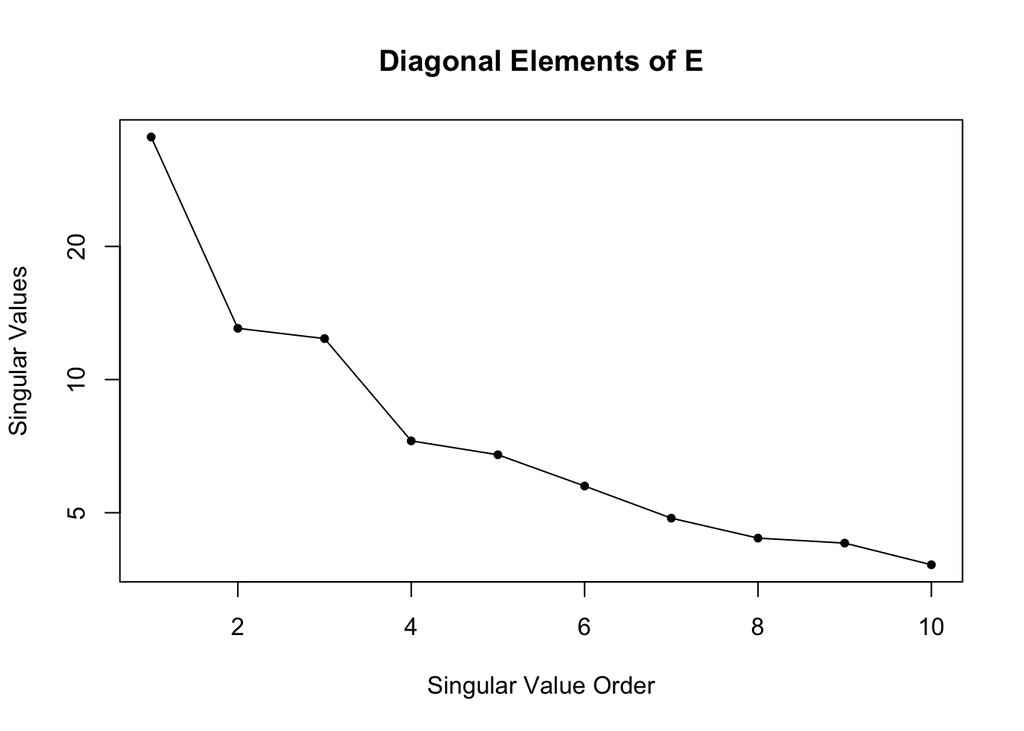

```r
plot(svdX$d, type = "o", log = "y",
     xlab = "Singular Value Order",
     ylab = "Singular Values",
     main = "Diagonal Elements of E",
     pch = 20)
```

**Answer:** *One left singular vector lies above 20 on the y axis (which are log values), and therefore seems very important. 2 points lie above 10 on the y axis, and could be argued to be important as well. The remaining 7 points lie below 8 and can therefore be argued to be not as important.*

## Question 5:

**Create a barplot of the first left singular vector as (code given). Judging by which bars are higher or lower, what is the first singular vector capturing? Describe in terms of media measurements (not mathematics).**

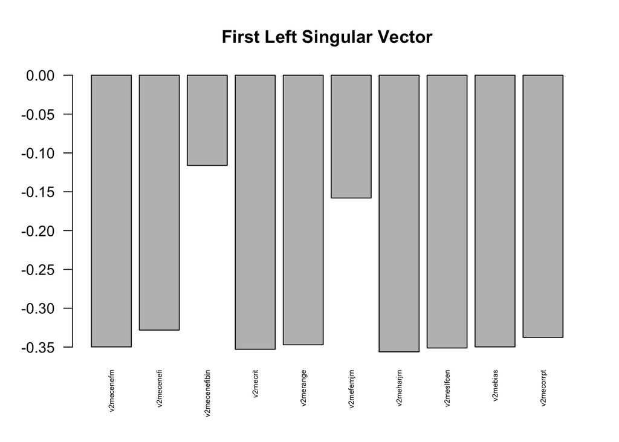

```r
# Code Given by Instructor:
barplot(svdX$u[,1],
        names.arg = varsMedia,
        cex.names=0.5,
        las = 2,
        main = "First Left Singular Vector")
```

**Answer:** *The first singular vector is showing which features that have the most significant impact on the most dominant variation of the data.*

## Question 6:

**The first column of V indicates how much weight each country puts on the first left singular vector. What are the five countries with the largest values in this first column of V? What are the five countries with the smallest values in this first column of V? Do the countries listed align with your interpretation in (5)?**

```r
dMedia$v1 <- svdX$v[,1]
head(dMedia$country_name[order(-dMedia$v1)],5) # Greatest Weight
```

```
## [1] "North Korea"  "Turkmenistan" "Eritrea"      "Syria"        "Laos"
```

```r
tail(dMedia$country_name[order(-dMedia$v1)],5) # Least Weight
```

```
## [1] "Estonia"     "Belgium"     "Sweden"      "Switzerland" "Denmark"
```

**Answer:** *The 5 countries with the largest values in the first column of V are North Korea, Turkmenistan, Eritrea, Syria, and Laos. This countries have historically had issues with freedom of speech and press perpetrated by the government. North Korea is ranked lowest in the World Press Freedom Index 2023.*

*On the other hand, the 5 countries with the lowest values in the first column of V are Estonia, Belgium, Sweden, Switzerland, Denmark - all of which have strong laws to promote freedom of press. Sweden was actually the first country in the world to adopt a press freedom law (in 1766).*

*Moreover, the countries with larger weights are all autocracies/dictatorships, while the countries with the smaller weight are all democracies. This aligns with the study’s measurement of democracies. Therefore, the countries listed do align with my interpretation in Q5.*

## Question 7:

**Which component of the second left singular vector is strikingly different from the rest?**

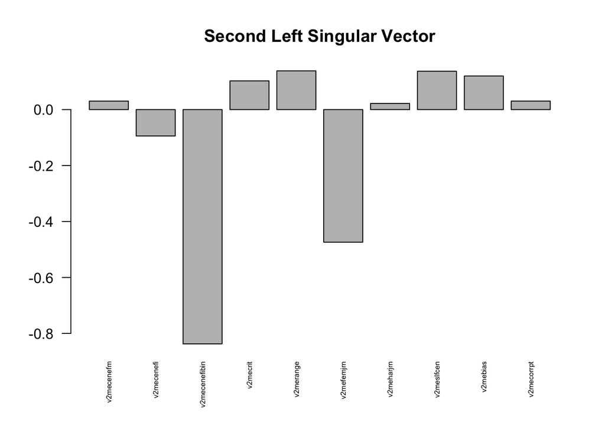

```r
barplot(svdX$u[,2],
        names.arg = varsMedia,
        cex.names=0.5,
        las = 2,
        main = "Second Left Singular Vector")
```

**Answer:** *Internet Availability (v2mecenefibin) is striking different, as it is significantly lower than the other components. Female journalists (v2mefemjrn) is also quite different for the second left singular vector. Both of these features’ weight are significantly lower than the weights of the other features, which lie betwee, -0.2 and +0.2.*

## Question 8:

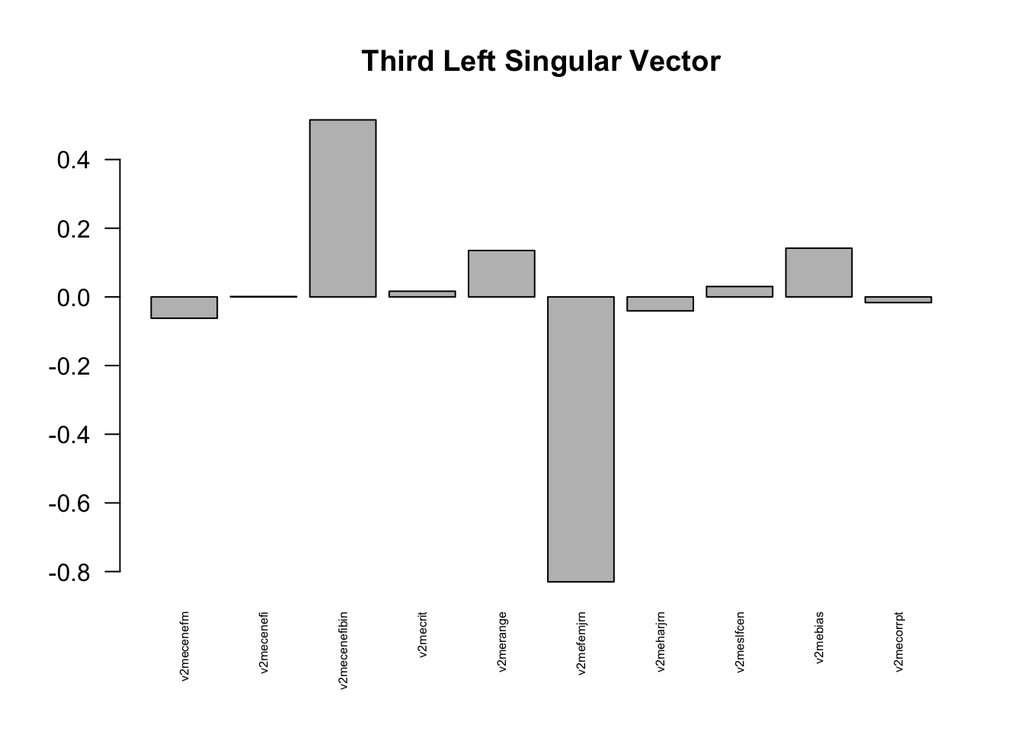

```r
barplot(svdX$u[,3],
        names.arg = varsMedia,
        cex.names=0.5,
        las = 2,
        main = "Third Left Singular Vector")
```

## Question 9:

**Create a scatterplot of `svdX$v[,1]` and `svdX$v[,2]`. These are the weights that each country applies to the first and second singular vectors. You may wish to use dMedia$country_text_id to mark each point so that you can determine which country is which.**

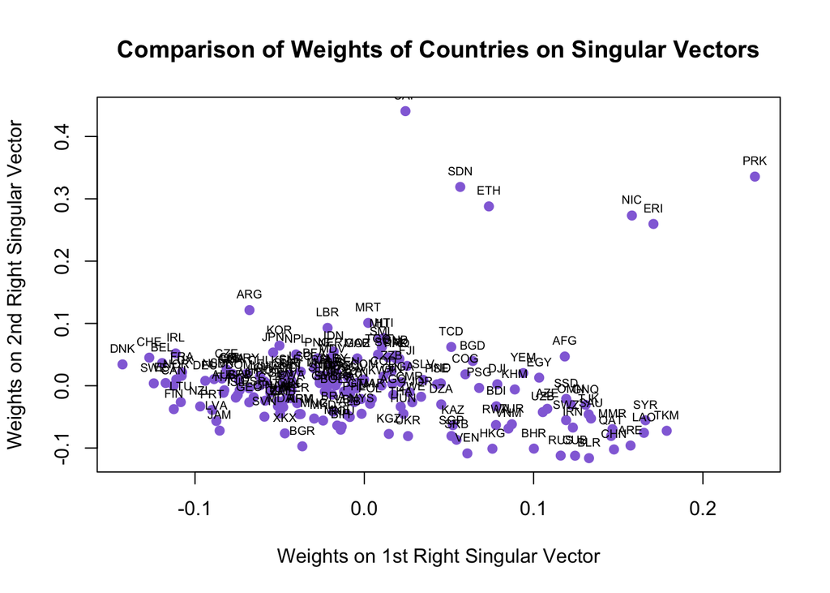

```r
plot(svdX$v[,1], svdX$v[,2],
     xlab="Weights on 1st Right Singular Vector",
     ylab="Weights on 2nd Right Singular Vector",
     main="Comparison of Weights of Countries on Singular Vectors",
     pch=19, col="mediumpurple")
text(svdX$v[,1],
     svdX$v[,2],
     labels = dMedia$country_text_id,
     pos = 3, cex = 0.6)
```

## Question 10:

**In the plot generated in (9), which countries are substantially separated from the others? What is the main feature that separates them from the other countries?**

```r
tempCountries <- c("CAF", "SDN", "ETH", "NIC", "ERI", "NIC", "ERI", "PRK")
dMedia$country_name[which(dMedia$country_text_id %in% tempCountries)]
```

```
## [1] "Sudan"                    "Ethiopia"
## [3] "North Korea"              "Nicaragua"
## [5] "Central African Republic" "Eritrea"
```

```r
for(i in 1:length(tempCountries)) {
  print(paste(dMedia$country_name[which(dMedia$country_text_id %in%
                                          tempCountries[i])],
              "---",
              varsMedia[which.max(abs(svdX$v[which(
                dMedia$country_text_id == tempCountries[i]),]))]))
}
```

```
## [1] "Central African Republic --- v2mecenefi"
## [1] "Sudan --- v2mecenefi"
## [1] "Ethiopia --- v2mecenefi"
## [1] "Nicaragua --- v2mecenefi"
## [1] "Eritrea --- v2mecenefi"
## [1] "Nicaragua --- v2mecenefi"
## [1] "Eritrea --- v2mecenefi"
## [1] "North Korea --- v2mecenefi"
```

## Question 11:

**Create a world map that shades each country based on the first column of V, the weight each country places on the first left singular vector. There are a variety of ways to do this in R, but the most straightforward may be to use ggplot2 and map_data().**

```r
# Code Given by Instructor:
library(ggplot2)
world <- map_data("world")
```

**To help you further, you may wish to attach the first right singular vector to dMedia.**

```r
# Code Given by Instructor:
dMedia$v1 <- svdX$v[,1]
```

**Some country names in world are not spelled exactly the same as in the V-Dem data. You should first correct the spelling differences before joining with dMedia.**

```r
# Code Given by Instructor:
world <- world |>
  mutate(region=case_match(region,
                           "USA" ~ "United States of America",
                           "UK" ~ "United Kingdom",
                           "Republic of Congo" ~ "Republic of the Congo",
                           "Myanmar" ~ "Burma/Myanmar",
                           "Czech Republic" ~ "Czechia",
                           .default = region)) |>
  left_join(dMedia |> select(country_name, v1),
            by=join_by(region==country_name))
```

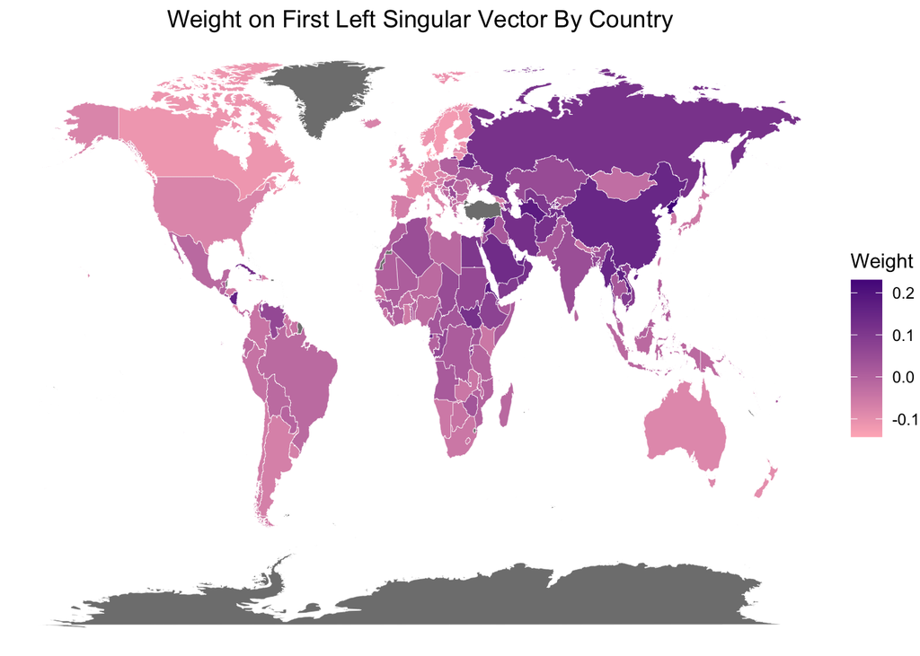

```r
ggplot(world, aes(x = long, y = lat, group = group, fill = v1)) +
  geom_polygon(color = "white", size = 0.1) +
  scale_fill_gradient(name = "Weight",
                      low = "lightpink", high = "purple4") +
  labs(title = "Weight on First Left Singular Vector By Country") +
  theme_void() +
  theme(plot.title = element_text(hjust = 0.5))
```

## Question 12:

**The following countries are former British colonies:**

```r
# Code Given by Instructor:
formerUKcolony <- c("AUS","AFG","BGD","BHR","BRB","BWA","CAN","CYP","EGY",
                    "SWZ","FJI","GHA","GUY","IND","IRL","IRQ","ISR","JAM",
                    "JOR","KEN","KWT","LSO","LBY","MWI","MDV","MLT","MUS",
                    "MMR","NGA","NZL","OMN","PAK","QAT","SYC","SLE","SLB",
                    "SML","YEM","LKA","SSD","GMB","TTO","UGA","ARE","USA",
                    "VUT","ZAF","ZMB","ZZB","ZWE")
```

**Use any machine learning method that we have previously studied to predict prior status as a British colony from the 10 right singular vectors. First, be sure to attach V to dMedia.**

```r
# Code Given by Instructor:
dMedia <- cbind(dMedia, V=svdX$v)
```

**Answer:** *Chosen Machine Learning Method:* *K-Nearest Neighbors*

```r
# Create UKcolony Column (0 = No, 1 = Yes)
dMedia$ukColony <- 0
dMedia$ukColony[which(dMedia$country_text_id %in% formerUKcolony)] <- 1

# Load the required packages
library(FNN)
library(dplyr)
library(tidyr)
library(doParallel)
```

```r
# Prepare the data
X <- dMedia[, c("V.1", "V.2", "V.3", "V.4", "V.5",
                "V.6", "V.7", "V.8", "V.9", "V.10")]
y <- dMedia$ukColony

# Determining the optimal value for K
set.seed(9292)
i <- c(1:nrow(X))
kval <- round(seq(1,100,length=50))
cl <- makeCluster(12)
registerDoParallel(cl)

bernLL <- foreach(j=1:length(kval), .combine = c, .packages = "FNN") %dopar%
  {
    knnPred <- FNN::knn.cv(train = X[i, ],
                           cl = y[i],
                           k = kval[j],
                           prob = TRUE)

    # Extract the predicted probabilities
    p <- attr(knnPred, "prob")
    p <- ifelse(knnPred==1, p, 1-p)
    p <- (p*kval[j] + 1)/(kval[j] + 2)

    # Compute average Bernoulli log-likelihood
    avebernLL <- mean(ifelse(y[i]==1, log(p), log(1-p)))

    return(avebernLL)
  }

stopCluster(cl)
kBest <- kval[which.max(bernLL)]
kBest # 27
```

```
## [1] 27
```

```r
max(bernLL) # -0.5605454
```

```
## [1] -0.5605454
```

```r
# Predicting Prior Status as a British Colony
predicted_colony <- knn(train = X[i,],
                        test = X,
                        cl = y[i],
                        k = kBest)

dMedia$predicted_ukColony <- predicted_colony

# UK Colonies vs Predicted UK Colonies
dMedia[,c("country_name","ukColony","predicted_ukColony")]
```

| country_name | ukColony | predicted_ukColony |
| --- | --- | --- |
| Mexico | 0 | 0 |
| Suriname | 0 | 1 |
| Sweden | 0 | 0 |
| Switzerland | 0 | 0 |
| Ghana | 1 | 0 |
| South Africa | 1 | 0 |
| Japan | 0 | 0 |
| Burma/Myanmar | 1 | 0 |
| Russia | 0 | 0 |
| Albania | 0 | 0 |

[output cut: 169 more lines]

```r
# Percent of Correct Predictions
100 * mean(dMedia$ukColony == dMedia$predicted_ukColony)
```

```
## [1] 74.86034
```